# Analysis of blood cell changes in sepsis.

Waweru JM

2025-02-28

## Abstract

### Introduction.

Sepsis is a clinical syndrome that defines human body reaction to infection by microbial pathogens. Delay in sepsis diagnosis and inappropriate treatment are associated with high mortality. Blood cell count is a major baseline laboratory investigation for a suspected case of sepsis. Multiple parameters are analyzed and reported in the complete blood cell count analysis that estimate human body immune response to microbial infection. Statistical analysis of blood cell changes in sepsis may reveal underlying structure that may assist in interpretation of initial blood cell laboratory results of suspected sepsis case and lead to improved diagnosis and better outcome of sepsis.

### Methodology:

Data from medical information mart for intensive care (MIMIC IV) database from Beth Israel Deaconess Medical Center was used to analyze the correlation of various blood cell components in sepsis. Statistical analysis was done using R software

### Results:

Factor analysis was performed on 83 individuals, described by fourteen (14) variables. Six components had eigen values greater than 1.0 with cumulative variance of 85.5%. Hematocrit, hemoglobin and red blood cells loaded uniquely in the first factor. Neutrophils, lymphocytes and monocytes loaded highly in the second factor. MCV and MCH loaded well in the third factor.

### Discussion and Conclusion;

Blood cell changes in sepsis occur mainly in three patterns described by hemoglobin changes, inflammatory changes and morphological changes. These categories may be used to interpret the initial blood cell results of a suspected case of sepsis.

## Data analysis

### 1. Loading initial R packages.

```r
knitr::opts_chunk$set(message=FALSE, warning=FALSE)

library(readxl)
library(tidyverse)
library(kableExtra)
```

### 2. Importing ICD dictionary used in MIMIC IV disease coding.

```r
icd_dictionery <- read.csv("C:/Users/HP/Documents/MIMIC IV/d_icd_diagnoses (1).csv.gz")

kable(head(icd_dictionery), booktabs = TRUE,
      align = "c", caption = "Table .1  A section of diseases and their respective icd codes as recorded in ICD dictionary.") |>
        kable_styling( bootstrap_options = "striped", "hover", full_width = FALSE)
```

Table .1 A section of diseases and their respective icd codes as recorded in ICD dictionary.

| icd_code | icd_version | long_title |
| --- | --- | --- |
| 0010 | 9 | Cholera due to vibrio cholerae |
| 0011 | 9 | Cholera due to vibrio cholerae el tor |
| 0019 | 9 | Cholera, unspecified |
| 0020 | 9 | Typhoid fever |
| 0021 | 9 | Paratyphoid fever A |
| 0022 | 9 | Paratyphoid fever B |

### 3. Glimpse at sepsis and similar diagnosis in the ICD dictionary.

```r
sepsis_similar_terms <-icd_dictionery |> filter(grepl( "sepsis", long_title))

kable(sepsis_similar_terms, booktabs = TRUE,
      align = "c",
      caption = "Table 2.  All sepsis and similar diagnosis in the ICD dictionary") |>
  kable_styling(full_width = F) |>
  scroll_box(width = "500px", height = "200px")|>
  row_spec(c(5,25, 26,27), color = "red")
```

Table 2. All sepsis and similar diagnosis in the ICD dictionary

| icd_code | icd_version | long_title |
| --- | --- | --- |
| 67020 | 9 | Puerperal sepsis, unspecified as to episode of care or not applicable |
| 67022 | 9 | Puerperal sepsis, delivered, with mention of postpartum complication |
| 67024 | 9 | Puerperal sepsis, postpartum condition or complication |
| 77181 | 9 | Septicemia [sepsis] of newborn |
| 99592 | 9 | Severe sepsis |
| A021 | 10 | Salmonella sepsis |
| A227 | 10 | Anthrax sepsis |
| A267 | 10 | Erysipelothrix sepsis |
| A327 | 10 | Listerial sepsis |
| A40 | 10 | Streptococcal sepsis |
| A408 | 10 | Other streptococcal sepsis |
| A409 | 10 | Streptococcal sepsis, unspecified |
| A41 | 10 | Other sepsis |
| A4150 | 10 | Gram-negative sepsis, unspecified |
| A4159 | 10 | Other Gram-negative sepsis |
| A418 | 10 | Other specified sepsis |
| A4189 | 10 | Other specified sepsis |
| A427 | 10 | Actinomycotic sepsis |
| A5486 | 10 | Gonococcal sepsis |
| B377 | 10 | Candidal sepsis |
| O85 | 10 | Puerperal sepsis |
| P36 | 10 | Bacterial sepsis of newborn |
| P368 | 10 | Other bacterial sepsis of newborn |
| P369 | 10 | Bacterial sepsis of newborn, unspecified |
| R652 | 10 | Severe sepsis |
| R6520 | 10 | Severe sepsis without septic shock |
| R6521 | 10 | Severe sepsis with septic shock |

### 4. Filtering codes specific to sepsis definition from icd 9 and icd 10 dictionary.

```r
sepsis_codes <- icd_dictionery |> filter(icd_code ==99591|icd_code ==99592|icd_code =="R652"|icd_code =="R6520"|icd_code =="R6521")

kable(sepsis_codes, align = "c", caption = "Table 3. Display of icd codes specific to sepsis diagnosis.") |>
  kable_styling(full_width = FALSE)
```

Table 3. Display of icd codes specific to sepsis diagnosis.

| icd_code | icd_version | long_title |
| --- | --- | --- |
| 99591 | 9 | Sepsis |
| 99592 | 9 | Severe sepsis |
| R652 | 10 | Severe sepsis |
| R6520 | 10 | Severe sepsis without septic shock |
| R6521 | 10 | Severe sepsis with septic shock |

### 5. Importing the patient admission records.

```r
admissions <- read.csv("C:/Users/HP/Documents/MIMIC IV/diagnoses_icd (1).csv.gz")

kable(tail(admissions), align = "c", caption = "Table 4. Record of subject_id with discharge icd_code diagnosis appended.") |>
  kable_styling(full_width = FALSE)
```

Table 4. Record of subject_id with discharge icd_code diagnosis appended.

|  | subject_id | hadm_id | seq_num | icd_code | icd_version |
| --- | --- | --- | --- | --- | --- |
| 6364515 | 19999987 | 23865745 | 6 | 2449 | 9 |
| 6364516 | 19999987 | 23865745 | 7 | 41401 | 9 |
| 6364517 | 19999987 | 23865745 | 8 | 78039 | 9 |
| 6364518 | 19999987 | 23865745 | 9 | 0413 | 9 |
| 6364519 | 19999987 | 23865745 | 10 | 36846 | 9 |
| 6364520 | 19999987 | 23865745 | 11 | 7810 | 9 |

### 6. Filtering patients with codes specific to sepsis from admissions record.

```r
admissions_sepsis <- admissions |> filter(icd_code ==99591|icd_code ==99592|icd_code =="R652"|icd_code =="R6520"|icd_code =="R6521")

kable(head(admissions_sepsis), align = "c", caption = "Table 5. Display of patients with sepsis diagnosis.") |>
  kable_styling(full_width = FALSE)
```

Table 5. Display of patients with sepsis diagnosis.

| subject_id | hadm_id | seq_num | icd_code | icd_version |
| --- | --- | --- | --- | --- |
| 10000826 | 21086876 | 2 | 99591 | 9 |
| 10001401 | 27012892 | 3 | R6520 | 10 |
| 10001843 | 26133978 | 6 | R6521 | 10 |
| 10002013 | 24848509 | 5 | 99592 | 9 |
| 10002428 | 23473524 | 6 | 99591 | 9 |
| 10002428 | 28662225 | 15 | 99592 | 9 |

### 7. Importing laboratory events

```r
laboratory_events <- read.csv("C:/Users/HP/Documents/MIMIC IV/labeventss (1).csv")

kable(head(laboratory_events), align = "c", caption = "Table 6. A section of laboratory events record.") |>
  kable_styling(full_width = FALSE)
```

Table 6. A section of laboratory events record.

| labevent_id | subject_id | hadm_id | specimen_id | itemid | order_provider_id | charttime | storetime | value | valuenum | valueuom | ref_range_lower | ref_range_upper | flag | priority | comments |
| --- | --- | --- | --- | --- | --- | --- | --- | --- | --- | --- | --- | --- | --- | --- | --- |
| 1 | 10000032 | NA | 2704548 | 50931 | P69FQC | 3/23/2180 11:51 | 3/23/2180 15:56 | ___ | 95 | mg/dL | 70 | 100 |  | ROUTINE | IF FASTING, 70-100 NORMAL, >125 PROVISIONAL DIABETES. |
| 2 | 10000032 | NA | 36092842 | 51071 | P69FQC | 3/23/2180 11:51 | 3/23/2180 16:00 | NEG | NA |  | NA | NA |  | ROUTINE |  |
| 3 | 10000032 | NA | 36092842 | 51074 | P69FQC | 3/23/2180 11:51 | 3/23/2180 16:00 | NEG | NA |  | NA | NA |  | ROUTINE |  |
| 4 | 10000032 | NA | 36092842 | 51075 | P69FQC | 3/23/2180 11:51 | 3/23/2180 16:00 | NEG | NA |  | NA | NA |  | ROUTINE | BENZODIAZEPINE IMMUNOASSAY SCREEN DOES NOT DETECT SOME DRUGS,;INCLUDING LORAZEPAM, CLONAZEPAM, AND FLUNITRAZEPAM. |
| 5 | 10000032 | NA | 36092842 | 51079 | P69FQC | 3/23/2180 11:51 | 3/23/2180 16:00 | NEG | NA |  | NA | NA |  | ROUTINE |  |
| 6 | 10000032 | NA | 36092842 | 51087 | P69FQC | 3/23/2180 11:51 |  |  | NA |  | NA | NA |  | ROUTINE | RANDOM. |

### 8. Filtering laboratory events for sepsis patients.

```r
labs_sepsis <- laboratory_events |> filter(subject_id %in% admissions_sepsis$subject_id)

kable(tail(labs_sepsis), align = "c", caption = "Table 7. Display of laboratory events for sepsis patients.") |>
  kable_styling(full_width = FALSE)
```

Table 7. Display of laboratory events for sepsis patients.

|  | labevent_id | subject_id | hadm_id | specimen_id | itemid | order_provider_id | charttime | storetime | value | valuenum | valueuom | ref_range_lower | ref_range_upper | flag | priority | comments |
| --- | --- | --- | --- | --- | --- | --- | --- | --- | --- | --- | --- | --- | --- | --- | --- | --- |
| 215372 | 1049721 | 10070614 | NA | 66926796 | 50821 |  | 1/30/2169 7:08 | 1/30/2169 7:17 | ___ | 25.00 | mm Hg | 85.0 | 105.0 | abnormal |  | PROVIDER NOTIFIED PER CURRENT LAB POLICY. |
| 215373 | 1049722 | 10070614 | NA | 66926796 | 50822 |  | 1/30/2169 7:08 | 1/30/2169 7:18 | 3.9 | 3.90 | mEq/L | 3.5 | 5.4 |  |  |  |
| 215374 | 1049723 | 10070614 | NA | 66926796 | 50824 |  | 1/30/2169 7:08 | 1/30/2169 7:18 | 127 | 127.00 | mEq/L | 135.0 | 147.0 | abnormal |  |  |
| 215375 | 1049724 | 10070614 | NA | 66926796 | 52024 |  | 1/30/2169 7:08 | 1/30/2169 7:18 | 1.46 | 1.46 | mg/dL | 0.5 | 1.2 | abnormal |  |  |
| 215376 | 1049725 | 10070614 | NA | 66926796 | 52026 |  | 1/30/2169 7:08 | 1/30/2169 7:18 |  | NA |  | NA | NA |  |  | ___ |
| 215377 | 1049726 | 10070614 | NA | 66926796 | 52033 |  | 1/30/2169 7:08 | 1/30/2169 7:13 | VEN. | NA |  | NA | NA |  |  | ___ |

### 9. Importing laboratory item_id dictionery

```r
lab_itemid <- read.csv("C:/Users/HP/Documents/MIMIC IV/d_labitems (1).csv.gz")

kable(head(lab_itemid), align = "c", caption = "Table 8. Display of laboratory item_id dictionary.") |>
  kable_styling()
```

Table 8. Display of laboratory item_id dictionary.

| itemid | label | fluid | category |
| --- | --- | --- | --- |
| 50801 | Alveolar-arterial Gradient | Blood | Blood Gas |
| 50802 | Base Excess | Blood | Blood Gas |
| 50803 | Calculated Bicarbonate, Whole Blood | Blood | Blood Gas |
| 50804 | Calculated Total CO2 | Blood | Blood Gas |
| 50805 | Carboxyhemoglobin | Blood | Blood Gas |
| 50806 | Chloride, Whole Blood | Blood | Blood Gas |

### 10. Glimpse at hematology laboratory item_id

```r
hematology_category <- lab_itemid |> filter(fluid=="Blood" & category == "Hematology")

kable(head(hematology_category), align = "c", caption = "Table 9. Display of blood specimen with hemaological investigation category") |>
  kable_styling(full_width = FALSE) |>
  scroll_box(width = "500px", height = "200px")
```

Table 9. Display of blood specimen with hemaological investigation category

| itemid | label | fluid | category |
| --- | --- | --- | --- |
| 51130 | Absolute CD3 Count | Blood | Hematology |
| 51131 | Absolute CD4 Count | Blood | Hematology |
| 51132 | Absolute CD8 Count | Blood | Hematology |
| 51133 | Absolute Lymphocyte Count | Blood | Hematology |
| 51134 | Acanthocytes | Blood | Hematology |
| 51135 | ADP | Blood | Hematology |

### 11. Developing a list of blood cell labels of study interest.

```r
bloodcell_labels <- c("Absolute Lymphocyte Count", "Basophils", "Eosinophil Count", "Eosinophils", "Granulocyte Count", "Hematocrit", "Hemoglobin", "Lymphocytes", "Lymphocytes, Percent","MCH", "MCHC", "MCV", "Monocyte Count", "Monocytes", "Neutrophils", "Platelet Count", "RDW", "Red Blood Cells","WBC Count", "White Blood Cells","Absolute Basophil Count","Absolute Eosinophil Count", "Absolute Monocyte Count", "Absolute Neutrophil Count","Rbc")
```

### 12. Filtering laboratory item_id specific to bloodcell labels of study interest.

```r
bloodcell_itemid <- hematology_category |> filter(label %in% bloodcell_labels)

kable(bloodcell_itemid, align = "c", caption = "Table 10. Display of bloodcell itemid of study interest.") |>
  kable_styling(full_width = FALSE) |>
  scroll_box(width = "600px", height = "300px")
```

Table 10. Display of bloodcell itemid of study interest.

| itemid | label | fluid | category |
| --- | --- | --- | --- |
| 51133 | Absolute Lymphocyte Count | Blood | Hematology |
| 51146 | Basophils | Blood | Hematology |
| 51199 | Eosinophil Count | Blood | Hematology |
| 51200 | Eosinophils | Blood | Hematology |
| 51218 | Granulocyte Count | Blood | Hematology |
| 51221 | Hematocrit | Blood | Hematology |
| 51222 | Hemoglobin | Blood | Hematology |
| 51244 | Lymphocytes | Blood | Hematology |
| 51245 | Lymphocytes, Percent | Blood | Hematology |
| 51248 | MCH | Blood | Hematology |
| 51249 | MCHC | Blood | Hematology |
| 51250 | MCV | Blood | Hematology |
| 51253 | Monocyte Count | Blood | Hematology |
| 51254 | Monocytes | Blood | Hematology |
| 51256 | Neutrophils | Blood | Hematology |
| 51265 | Platelet Count | Blood | Hematology |
| 51277 | RDW | Blood | Hematology |
| 51279 | Red Blood Cells | Blood | Hematology |
| 51300 | WBC Count | Blood | Hematology |
| 51301 | White Blood Cells | Blood | Hematology |
| 52069 | Absolute Basophil Count | Blood | Hematology |
| 52073 | Absolute Eosinophil Count | Blood | Hematology |
| 52074 | Absolute Monocyte Count | Blood | Hematology |
| 52075 | Absolute Neutrophil Count | Blood | Hematology |
| 52769 | Absolute Lymphocyte Count | Blood | Hematology |

### 13. Scoop laboratory value related to each item_id, loop and merge into data frame by subject_id.

```r
data0 <- labs_sepsis |> select(subject_id) |> distinct()

for (i in bloodcell_itemid$itemid) {

    data01<- labs_sepsis |>  filter(itemid==i) |>
      group_by (subject_id) |>
      arrange(subject_id) |>
      arrange (charttime) |> filter(row_number()==1) |>
      select(subject_id, value) |>
      merge(data0,data01,by.x = "subject_id" ,by.y = "subject_id", all=TRUE, sort = TRUE)


      data0 <- data01
}

  data02<- data01[!duplicated(as.list(data01))]
  names(data02) [-1] <- rev(bloodcell_itemid$label)

kable(head(data02), align = "c", caption = "Table 11. Display of data frame of blood cell values for sepsis patients.") |>
  kable_styling(full_width = FALSE)
```

Table 11. Display of data frame of blood cell values for sepsis patients.

| subject_id | Absolute Lymphocyte Count | Absolute Neutrophil Count | Absolute Monocyte Count | Absolute Eosinophil Count | Absolute Basophil Count | White Blood Cells | WBC Count | Red Blood Cells | RDW | Platelet Count | Neutrophils | Monocytes | Monocyte Count | MCV | MCHC | MCH | Lymphocytes, Percent | Lymphocytes | Hemoglobin | Hematocrit | Granulocyte Count | Eosinophils | Eosinophil Count | Basophils | Absolute Lymphocyte Count |
| --- | --- | --- | --- | --- | --- | --- | --- | --- | --- | --- | --- | --- | --- | --- | --- | --- | --- | --- | --- | --- | --- | --- | --- | --- | --- |
| 10000826 | NA | NA | NA | NA | NA | 13 | NA | 2.9 | 14 | 146 | 60.7 | 7.3 | NA | 104 | 32.7 | 34.1 | NA | 28.3 | 9.9 | 30.2 | NA | 2.8 | NA | 0.9 | NA |
| 10001401 | NA | 9.34 | 0.93 | 0.15 | 0.01 | 6.1 | NA | 2.98 | 13.9 | 278 | 78.5 | 7.8 | NA | 102 | 29.7 | 30.2 | NA | 10.8 | 9 | 30.3 | NA | 1.3 | NA | 0.1 | 1.29 |
| 10001843 | NA | 8.99 | 0.71 | 0.01 | 0.02 | 13.8 | NA | 3.42 | 22.4 | 203 | 86.6 | 6.8 | NA | 95 | 29.3 | 27.8 | NA | 5.1 | 9.5 | 36.8 | NA | 0.1 | NA | 0.2 | 0.53 |
| 10002013 | NA | 7.32 | 1.15 | 0.12 | 0.07 | 7.9 | NA | 3.63 | 12.8 | 254 | 63.2 | 4.7 | NA | 99 | 34.2 | 33.7 | NA | 30.4 | 12.2 | 35.8 | NA | 1.2 | NA | 0.5 | 4.03 |
| 10002428 | NA | 8.09 | 0.79 | 0.04 | 0.05 | 8.7 | NA | 3.79 | 13 | 319 | 93.6 | 2.4 | NA | 95 | 33.6 | 31.8 | NA | 3.6 | 12.1 | 35.8 | NA | 0.1 | NA | 0.2 | 1.06 |
| 10003019 | 1704 | 7.82 | 1.18 | 0.51 | 0.09 | ___ | 28.4 | 3.74 | 18.4 | 294 | 87 | 1 | NA | 94 | 31.7 | 29.8 | 6 | 5 | 11.1 | 35.2 | NA | 0 | NA | 1 | 2.73 |

### 14. Standardizing column names to snake_case format.

```r
library(janitor)

sepsis_data <- clean_names(data02)

kable(head(sepsis_data), align = "c", caption = "Table 12. Sepsis data frame with clean column names.") |>
  kable_styling(full_width = FALSE)
```

Table 12. Sepsis data frame with clean column names.

| subject_id | absolute_lymphocyte_count | absolute_neutrophil_count | absolute_monocyte_count | absolute_eosinophil_count | absolute_basophil_count | white_blood_cells | wbc_count | red_blood_cells | rdw | platelet_count | neutrophils | monocytes | monocyte_count | mcv | mchc | mch | lymphocytes_percent | lymphocytes | hemoglobin | hematocrit | granulocyte_count | eosinophils | eosinophil_count | basophils | absolute_lymphocyte_count_2 |
| --- | --- | --- | --- | --- | --- | --- | --- | --- | --- | --- | --- | --- | --- | --- | --- | --- | --- | --- | --- | --- | --- | --- | --- | --- | --- |
| 10000826 | NA | NA | NA | NA | NA | 13 | NA | 2.9 | 14 | 146 | 60.7 | 7.3 | NA | 104 | 32.7 | 34.1 | NA | 28.3 | 9.9 | 30.2 | NA | 2.8 | NA | 0.9 | NA |
| 10001401 | NA | 9.34 | 0.93 | 0.15 | 0.01 | 6.1 | NA | 2.98 | 13.9 | 278 | 78.5 | 7.8 | NA | 102 | 29.7 | 30.2 | NA | 10.8 | 9 | 30.3 | NA | 1.3 | NA | 0.1 | 1.29 |
| 10001843 | NA | 8.99 | 0.71 | 0.01 | 0.02 | 13.8 | NA | 3.42 | 22.4 | 203 | 86.6 | 6.8 | NA | 95 | 29.3 | 27.8 | NA | 5.1 | 9.5 | 36.8 | NA | 0.1 | NA | 0.2 | 0.53 |
| 10002013 | NA | 7.32 | 1.15 | 0.12 | 0.07 | 7.9 | NA | 3.63 | 12.8 | 254 | 63.2 | 4.7 | NA | 99 | 34.2 | 33.7 | NA | 30.4 | 12.2 | 35.8 | NA | 1.2 | NA | 0.5 | 4.03 |
| 10002428 | NA | 8.09 | 0.79 | 0.04 | 0.05 | 8.7 | NA | 3.79 | 13 | 319 | 93.6 | 2.4 | NA | 95 | 33.6 | 31.8 | NA | 3.6 | 12.1 | 35.8 | NA | 0.1 | NA | 0.2 | 1.06 |
| 10003019 | 1704 | 7.82 | 1.18 | 0.51 | 0.09 | ___ | 28.4 | 3.74 | 18.4 | 294 | 87 | 1 | NA | 94 | 31.7 | 29.8 | 6 | 5 | 11.1 | 35.2 | NA | 0 | NA | 1 | 2.73 |

### 15. Standardizing missing value labels to all read as ‘NA’.

```r
sepsis_data0 <- sepsis_data |> mutate(across(where(is.character), ~na_if(.,"___")))
```

### 16.Standardizing variable format to ‘as numeric’.

```r
sepsis_data1 <- sepsis_data0 |> mutate_at( c(2:26), as.numeric)
#view(sepsis_data1)
```

### 17. Pattern and extent of missing values column-wise.

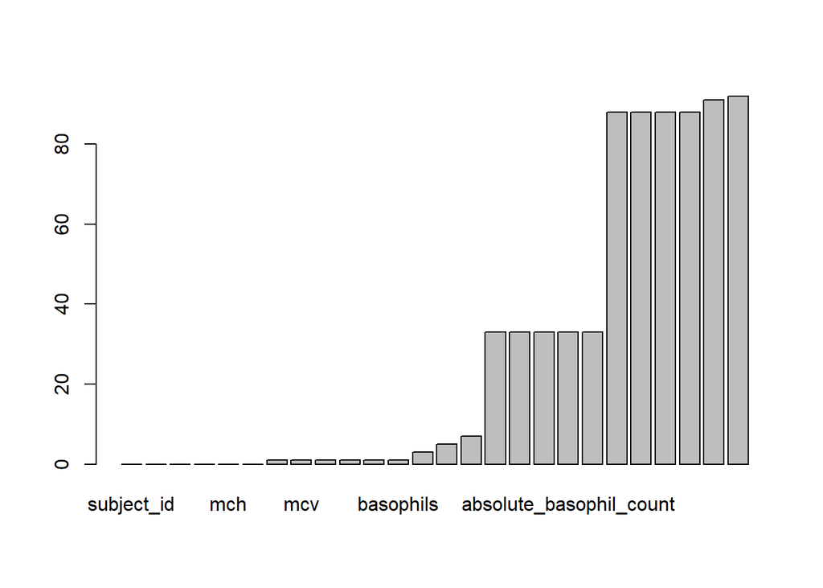

```r
columns_NA <- colSums(is.na(sepsis_data1))

barplot(sort(columns_NA))
```

```r
kable(sort(columns_NA), align = "c", caption = "Table 13. Missing values by columns.") |>
  kable_styling(full_width = FALSE) |>
  scroll_box(width = 250,height = 250)
```

Table 13. Missing values by columns.

|  | x |
| --- | --- |
| subject_id | 0 |
| red_blood_cells | 0 |
| rdw | 0 |
| mchc | 0 |
| mch | 0 |
| hemoglobin | 0 |
| monocytes | 1 |
| mcv | 1 |
| lymphocytes | 1 |
| hematocrit | 1 |
| eosinophils | 1 |
| basophils | 1 |
| white_blood_cells | 3 |
| platelet_count | 5 |
| neutrophils | 7 |
| absolute_neutrophil_count | 33 |
| absolute_monocyte_count | 33 |
| absolute_eosinophil_count | 33 |
| absolute_basophil_count | 33 |
| absolute_lymphocyte_count_2 | 33 |
| absolute_lymphocyte_count | 88 |
| wbc_count | 88 |
| lymphocytes_percent | 88 |
| granulocyte_count | 88 |
| eosinophil_count | 91 |
| monocyte_count | 92 |

### 18. Selection of columns with distinct blood cell variables.

```r
sepsis_data2 <- sepsis_data1[ , columns_NA<10]

kable(head(sepsis_data2), align = "c", caption = "Table 14. Sepsis data frame with distinct blood cell variables.") |>
  kable_styling(full_width = FALSE) |>
  scroll_box(width = 250,height = 250)
```

Table 14. Sepsis data frame with distinct blood cell variables.

| subject_id | white_blood_cells | red_blood_cells | rdw | platelet_count | neutrophils | monocytes | mcv | mchc | mch | lymphocytes | hemoglobin | hematocrit | eosinophils | basophils |
| --- | --- | --- | --- | --- | --- | --- | --- | --- | --- | --- | --- | --- | --- | --- |
| 10000826 | 13.0 | 2.90 | 14.0 | 146 | 60.7 | 7.3 | 104 | 32.7 | 34.1 | 28.3 | 9.9 | 30.2 | 2.8 | 0.9 |
| 10001401 | 6.1 | 2.98 | 13.9 | 278 | 78.5 | 7.8 | 102 | 29.7 | 30.2 | 10.8 | 9.0 | 30.3 | 1.3 | 0.1 |
| 10001843 | 13.8 | 3.42 | 22.4 | 203 | 86.6 | 6.8 | 95 | 29.3 | 27.8 | 5.1 | 9.5 | 36.8 | 0.1 | 0.2 |
| 10002013 | 7.9 | 3.63 | 12.8 | 254 | 63.2 | 4.7 | 99 | 34.2 | 33.7 | 30.4 | 12.2 | 35.8 | 1.2 | 0.5 |
| 10002428 | 8.7 | 3.79 | 13.0 | 319 | 93.6 | 2.4 | 95 | 33.6 | 31.8 | 3.6 | 12.1 | 35.8 | 0.1 | 0.2 |
| 10003019 | NA | 3.74 | 18.4 | 294 | 87.0 | 1.0 | 94 | 31.7 | 29.8 | 5.0 | 11.1 | 35.2 | 0.0 | 1.0 |

### 19. Visualization of missing values row_wise.

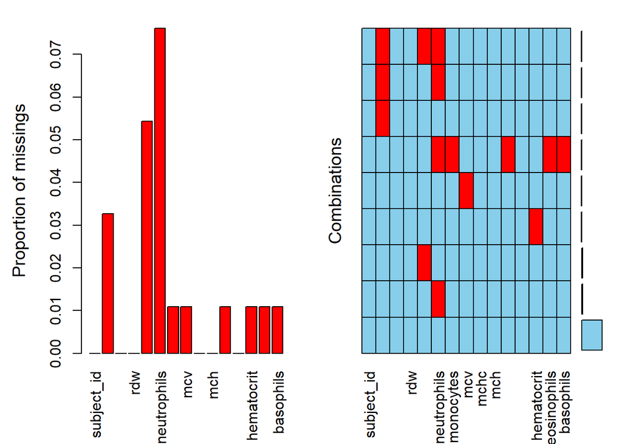

```r
library(VIM)

VIM::aggr (sepsis_data2)
```

### 20. Imputation of missing values.

```r
library(mice)

sepsis_data3 <- sepsis_data2 |> select(-1)

sepsis_data4 <- mice(sepsis_data3)
sepsis_data5 <-  complete(sepsis_data4, 2)
```

### 21. Multivariate distribution and correlation assesment

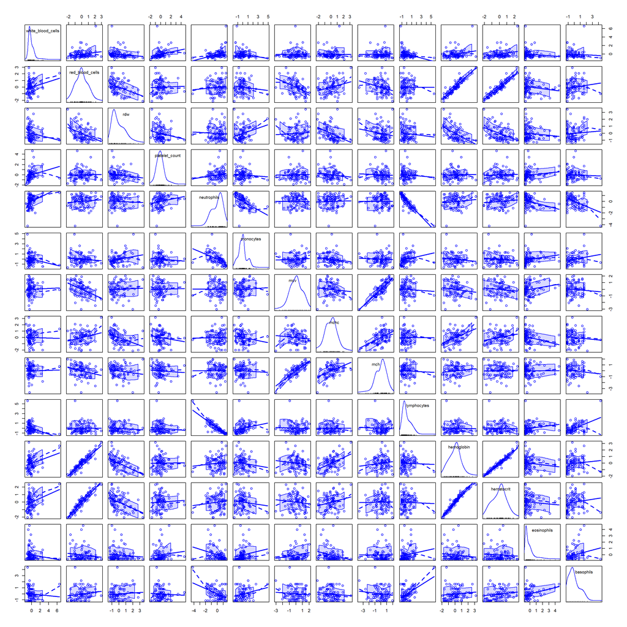

```r
library(car)

scatterplotMatrix(scale(sepsis_data5))
```

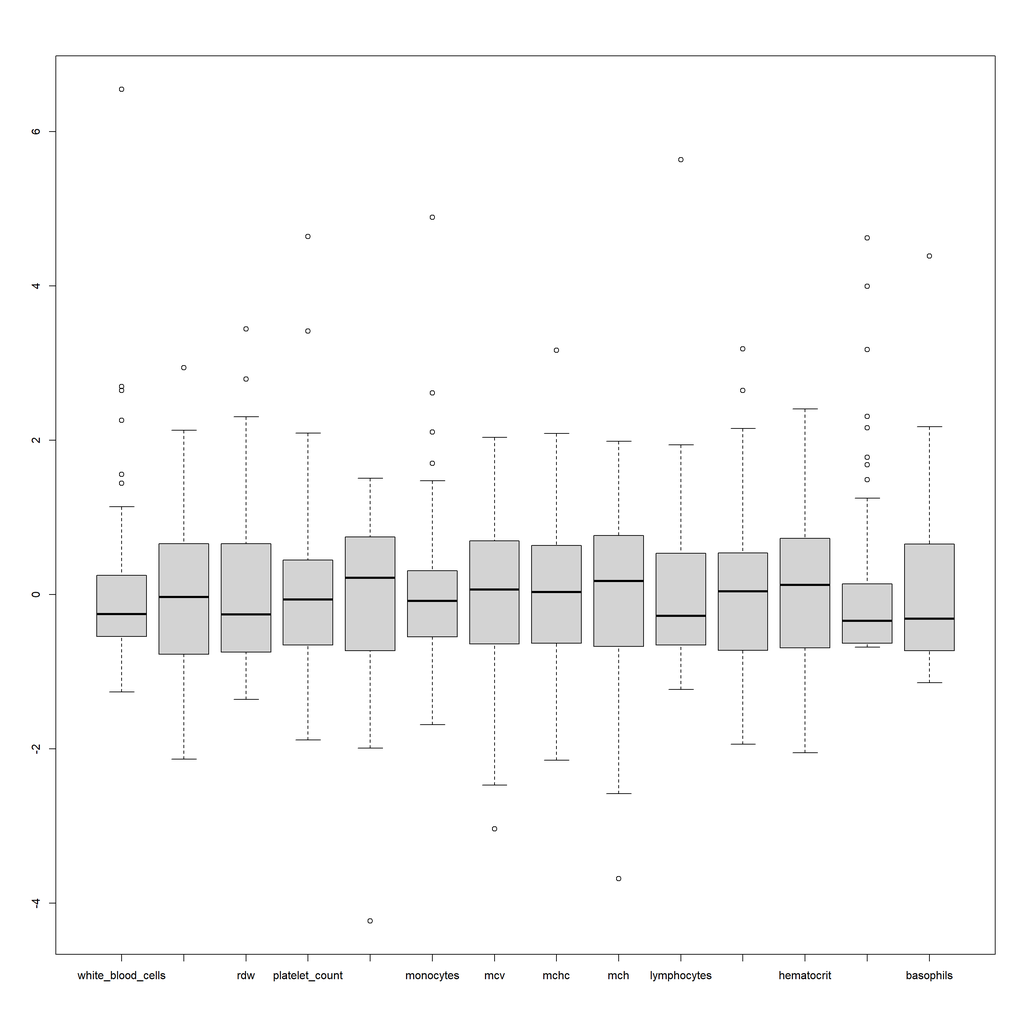

```r
boxplot(scale(sepsis_data5))
```

### 22. Multivariate skew and kurtosis

```r
library(psych)

skew_value <- skew(sepsis_data5)

kurtosis <- kurtosi(sepsis_data5)

shapiro_function <- function(x)(shapiro.test(x)$p.value)

skew_kurtosis <- data.frame(skew_value, kurtosis)

skew_kurtosis |>
  mutate( shapiro_pvalue = sapply(sepsis_data5,shapiro_function)) |>
  kable(align = "c", caption = "Table 15. Display of skew, kurtosis and shapiro test p values of each variable.") |>
  kable_styling() |>
  scroll_box(width = 250,height = 250)
```

Table 15. Display of skew, kurtosis and shapiro test p values of each variable.

|  | skew_value | kurtosis | shapiro_pvalue |
| --- | --- | --- | --- |
| white_blood_cells | 3.5871377 | 18.6605906 | 0.0000000 |
| red_blood_cells | 0.3008671 | -0.1637339 | 0.5642908 |
| rdw | 1.0218237 | 0.6909656 | 0.0000148 |
| platelet_count | 1.5392414 | 4.7990066 | 0.0000024 |
| neutrophils | -0.9727177 | 1.7739791 | 0.0001315 |
| monocytes | 1.4666706 | 4.8972950 | 0.0000049 |
| mcv | -0.3114671 | -0.0358335 | 0.3845896 |
| mchc | 0.1783332 | 0.2035920 | 0.5817934 |
| mch | -0.7634556 | 1.1267755 | 0.0110438 |
| lymphocytes | 2.1712927 | 8.8999743 | 0.0000000 |
| hemoglobin | 0.3932699 | 0.3013562 | 0.1874178 |
| hematocrit | 0.0383875 | -0.5121025 | 0.5258239 |
| eosinophils | 2.4694265 | 6.7932023 | 0.0000000 |
| basophils | 1.2053984 | 2.4014800 | 0.0000012 |

### 22. Multivariate outlier assesment

```r
#mahalanobis(sepsis_data5,colMeans(sepsis_data5), cov(sepsis_data5))

sepsis_mahalanobis <- sepsis_data5 |>
  mutate(mahalanob_value =mahalanobis(sepsis_data5,colMeans(sepsis_data5), cov(sepsis_data5)))

pvalue_mahalanobis <- sepsis_mahalanobis |>
mutate(mahalanob_pvalue = pchisq(mahalanob_value, df = 13, lower.tail = FALSE))

kable(head(pvalue_mahalanobis),align = "c", caption = "Table 16. Display of section of data with mahalanobis value and p_values.") |>
  kable_styling(full_width = FALSE) |>scroll_box(width = 250,height = 250)
```

Table 16. Display of section of data with mahalanobis value and p_values.

| white_blood_cells | red_blood_cells | rdw | platelet_count | neutrophils | monocytes | mcv | mchc | mch | lymphocytes | hemoglobin | hematocrit | eosinophils | basophils | mahalanob_value | mahalanob_pvalue |
| --- | --- | --- | --- | --- | --- | --- | --- | --- | --- | --- | --- | --- | --- | --- | --- |
| 13.0 | 2.90 | 14.0 | 146 | 60.7 | 7.3 | 104 | 32.7 | 34.1 | 28.3 | 9.9 | 30.2 | 2.8 | 0.9 | 12.128614 | 0.5171268 |
| 6.1 | 2.98 | 13.9 | 278 | 78.5 | 7.8 | 102 | 29.7 | 30.2 | 10.8 | 9.0 | 30.3 | 1.3 | 0.1 | 17.845781 | 0.1634633 |
| 13.8 | 3.42 | 22.4 | 203 | 86.6 | 6.8 | 95 | 29.3 | 27.8 | 5.1 | 9.5 | 36.8 | 0.1 | 0.2 | 53.365649 | 0.0000008 |
| 7.9 | 3.63 | 12.8 | 254 | 63.2 | 4.7 | 99 | 34.2 | 33.7 | 30.4 | 12.2 | 35.8 | 1.2 | 0.5 | 6.579766 | 0.9224911 |
| 8.7 | 3.79 | 13.0 | 319 | 93.6 | 2.4 | 95 | 33.6 | 31.8 | 3.6 | 12.1 | 35.8 | 0.1 | 0.2 | 4.840533 | 0.9785377 |
| 13.8 | 3.74 | 18.4 | 294 | 87.0 | 1.0 | 94 | 31.7 | 29.8 | 5.0 | 11.1 | 35.2 | 0.0 | 1.0 | 15.265663 | 0.2910629 |

```r
sepsis_ouliers <- pvalue_mahalanobis |> filter(mahalanob_pvalue < 0.001) |> select(mahalanob_value, mahalanob_pvalue)

kable(head(sepsis_ouliers),align = "c", caption = "Table 16. Display of outliers with corresponding mahalanobis value and p_values.") |>
  kable_styling(full_width = FALSE) |>scroll_box(width = 250,height = 250)
```

Table 16. Display of outliers with corresponding mahalanobis value and p_values.

| mahalanob_value | mahalanob_pvalue |
| --- | --- |
| 53.36565 | 0.0000008 |
| 37.08241 | 0.0004022 |
| 42.07986 | 0.0000636 |
| 38.76855 | 0.0002177 |
| 42.13207 | 0.0000623 |
| 45.81841 | 0.0000153 |

```r
sepsis_data6 <- pvalue_mahalanobis |> filter(mahalanob_pvalue > 0.001) |> select(-mahalanob_value, -mahalanob_pvalue)
#view(sepsis_data6)
```

### 23. Average blood cell values in sepsis

```r
sepsis_data6 |>
  summarise(across(1:14, ~ c(min(.x),round( mean(.x),digits = 1), max(.x)))) |>
  t() |>
  as.data.frame() |>
  rename( min_value=V1,mean =V2,max_value = V3) |>
  kable(align = "c", caption = "Table 17. Display of average blood cell values in sepsis.")|>kable_styling(full_width = FALSE)
```

Table 17. Display of average blood cell values in sepsis.

|  | min_value | mean | max_value |
| --- | --- | --- | --- |
| white_blood_cells | 0.10 | 9.8 | 31.10 |
| red_blood_cells | 2.31 | 3.7 | 5.52 |
| rdw | 12.20 | 15.3 | 21.20 |
| platelet_count | 21.00 | 240.2 | 741.00 |
| neutrophils | 50.00 | 76.5 | 95.20 |
| monocytes | 0.00 | 6.6 | 17.00 |
| mcv | 78.00 | 93.1 | 107.00 |
| mchc | 29.30 | 32.5 | 35.80 |
| mch | 24.00 | 30.2 | 34.80 |
| lymphocytes | 1.00 | 13.5 | 33.80 |
| hemoglobin | 6.60 | 11.3 | 16.50 |
| hematocrit | 20.80 | 34.7 | 47.60 |
| eosinophils | 0.00 | 1.5 | 11.00 |
| basophils | 0.00 | 0.4 | 1.00 |

### 24. Category of white cell changes in sepsis.

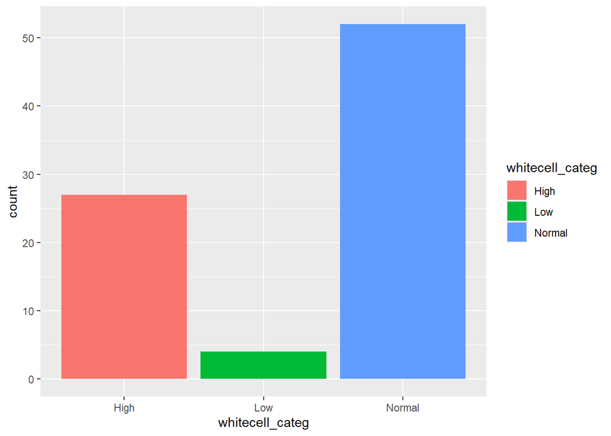

```r
whitecell_categories <- sepsis_data6 |>
  mutate(whitecell_categ= case_when(white_blood_cells < 4.0 ~"Low", white_blood_cells > 11.0 ~"High", white_blood_cells >=  4.0 ~"Normal"),.before = white_blood_cells)

category_plot <- whitecell_categories |>
ggplot(aes(whitecell_categ)) +
  geom_bar(mapping = aes(fill = whitecell_categ))
print(category_plot)
```

### 25. Factor analysis

```r
library(psych)
library(FactoMineR)
library(GPArotation)

describe(sepsis_data6)
```

|  | vars | n | mean | sd | median | trimmed | mad | min | max | range | skew | kurtosis | se |
| --- | --- | --- | --- | --- | --- | --- | --- | --- | --- | --- | --- | --- | --- |
| white_blood_cells | 1 | 83 | 9.8240964 | 5.7260336 | 8.50 | 8.982090 | 4.15128 | 0.10 | 31.10 | 31.00 | 1.698875367 | 3.4914889 | 0.62851384 |
| red_blood_cells | 2 | 83 | 3.7496386 | 0.7410629 | 3.76 | 3.751791 | 0.81543 | 2.31 | 5.52 | 3.21 | 0.041253034 | -0.7174699 | 0.08134222 |
| rdw | 3 | 83 | 15.2614458 | 2.0842517 | 14.70 | 15.080597 | 1.92738 | 12.20 | 21.20 | 9.00 | 0.700450020 | -0.4162823 | 0.22877635 |
| platelet_count | 4 | 83 | 240.2168675 | 109.1672523 | 224.00 | 229.134328 | 80.06040 | 21.00 | 741.00 | 720.00 | 1.627520871 | 5.0544765 | 11.98266267 |
| neutrophils | 5 | 83 | 76.4698795 | 11.5338075 | 78.80 | 76.965672 | 12.15732 | 50.00 | 95.20 | 45.20 | -0.407696552 | -0.9178826 | 1.26599985 |
| monocytes | 6 | 83 | 6.5963855 | 3.3887348 | 6.40 | 6.456716 | 2.37216 | 0.00 | 17.00 | 17.00 | 0.533461314 | 0.2640745 | 0.37196196 |
| mcv | 7 | 83 | 93.1445783 | 6.5166439 | 93.00 | 93.179104 | 7.41300 | 78.00 | 107.00 | 29.00 | -0.023188693 | -0.6736035 | 0.71529459 |
| mchc | 8 | 83 | 32.4843373 | 1.4496831 | 32.50 | 32.479104 | 1.48260 | 29.30 | 35.80 | 6.50 | 0.022409681 | -0.4017540 | 0.15912339 |
| mch | 9 | 83 | 30.2301205 | 2.2366534 | 30.50 | 30.308955 | 2.52042 | 24.00 | 34.80 | 10.80 | -0.391297462 | -0.2464783 | 0.24550460 |
| lymphocytes | 10 | 83 | 13.5216867 | 8.4929246 | 11.00 | 12.873134 | 8.89560 | 1.00 | 33.80 | 32.80 | 0.608436310 | -0.7260018 | 0.93221958 |

[output cut: 4 more lines]

```r
kmo_measure <- KMO(sepsis_data6)
print(kmo_measure)
```

```
## Kaiser-Meyer-Olkin factor adequacy
## Call: KMO(r = sepsis_data6)
## Overall MSA =  0.53
## MSA for each item =
## white_blood_cells   red_blood_cells               rdw    platelet_count
##              0.72              0.82              0.70              0.56
##       neutrophils         monocytes               mcv              mchc
##              0.50              0.46              0.35              0.28
##               mch       lymphocytes        hemoglobin        hematocrit
##              0.33              0.51              0.75              0.68
##       eosinophils         basophils
##              0.34              0.55
```

```r
bartlett_test <- cortest.bartlett(sepsis_data6)
print(bartlett_test)
```

```
## $chisq
## [1] 1673.978
##
## $p.value
## [1] 2.162928e-289
##
## $df
## [1] 91
```

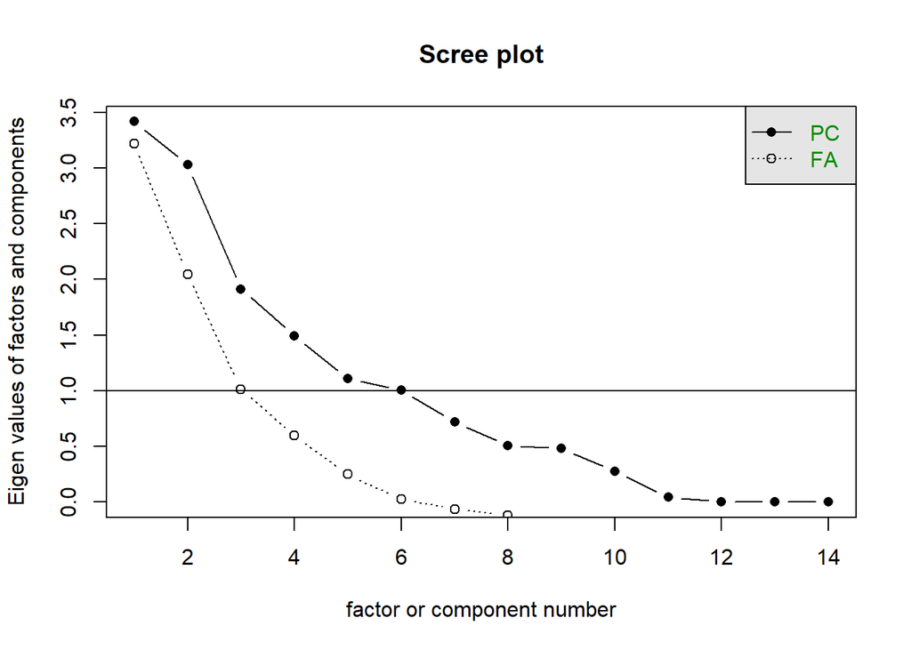

```r
sepsis_data7 <- scale(sepsis_data6)

scree_plot <- scree(sepsis_data7)
```

```r
factor_sepsis <- fa(sepsis_data7, nfactors = 6)

loadings <- factor_sepsis$loadings
print(loadings)
```

```
##
## Loadings:
##                   MR1    MR2    MR3    MR4    MR6    MR5
## white_blood_cells                              0.775
## red_blood_cells    0.931        -0.254
## rdw               -0.177                0.687 -0.163 -0.195
## platelet_count                                 0.440  0.175
## neutrophils              -1.020
## monocytes                 0.659  0.137  0.272        -0.151
## mcv                              0.946  0.232         0.111
## mchc                                   -0.664 -0.199 -0.278
## mch                              0.942 -0.265
## lymphocytes               0.808
## hemoglobin         0.961               -0.128
## hematocrit         1.023
## eosinophils                                           0.778
## basophils          0.324  0.139  0.123  0.175 -0.287  0.345
##
##                  MR1   MR2   MR3   MR4   MR6   MR5
## SS loadings    2.990 2.160 1.908 1.181 0.961 0.929
## Proportion Var 0.214 0.154 0.136 0.084 0.069 0.066
## Cumulative Var 0.214 0.368 0.504 0.589 0.657 0.724
```

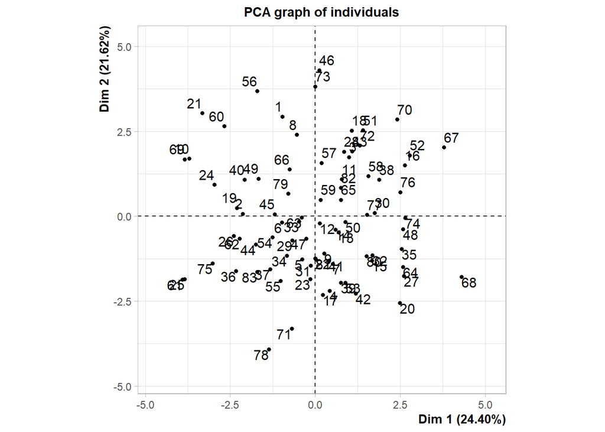

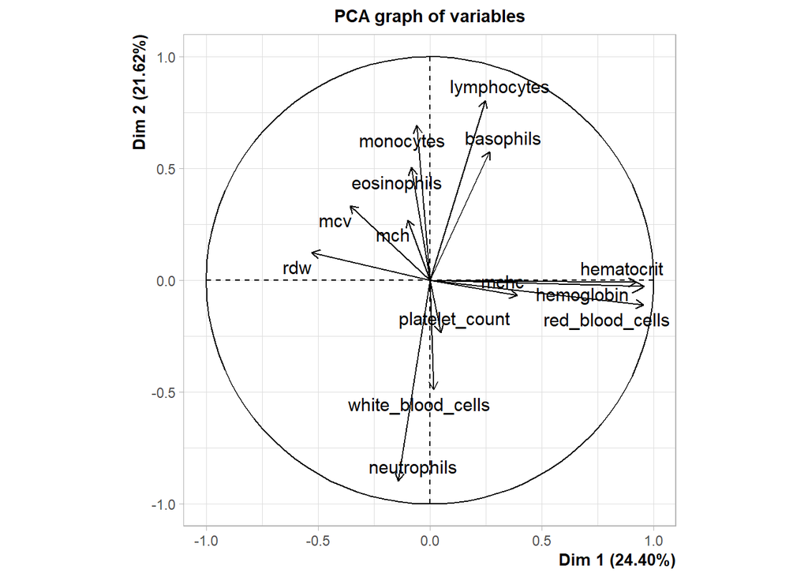

```r
pca_graphs <- PCA(sepsis_data7)
```